# How Efficient Is the Windy City?

Fall 2026

## The question

**Chicago’s big buildings must report their energy use every year. Are they actually getting more efficient?**

- Data: Chicago Energy Benchmarking, City of Chicago Data Portal (28,329 building-year records, 2014-2023)
- Main measure: **Site EUI** = energy used per square foot per year
- Four questions:
  1. Is the improvement real?
  2. Do older buildings waste more energy?
  3. Did COVID change energy use, and did it last?
  4. Which property types drive emissions?

## Cleaning: what I fixed and why

- Numbers were stored as **text with commas**, so I converted them
- “Submitted” vs “Submitted Data” labels differ in 2020 and 2022, so I merged them (otherwise two years vanish)
- Neighborhood names had **inconsistent capitalization**, so I standardized them
- Extreme EUI values (up to **15,634**) were removed above 500 (96 records)
- Created new variables: construction **era**, fuel **gas share**, size groups, COVID **period**
- Final analysis set: **22,544** submitted building-years

## Q1: Median energy intensity fell, mostly in a step in 2020

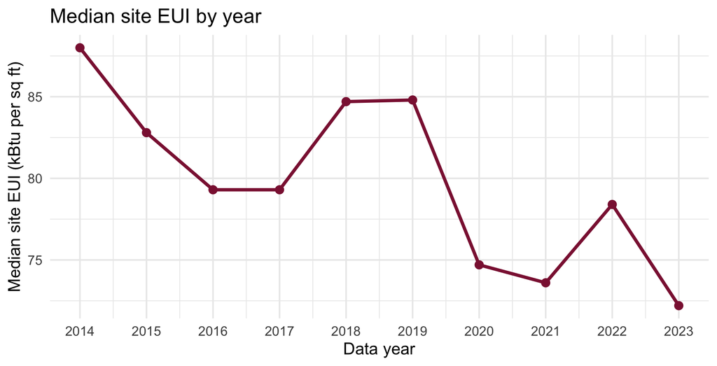

## Q1: The same buildings improved too

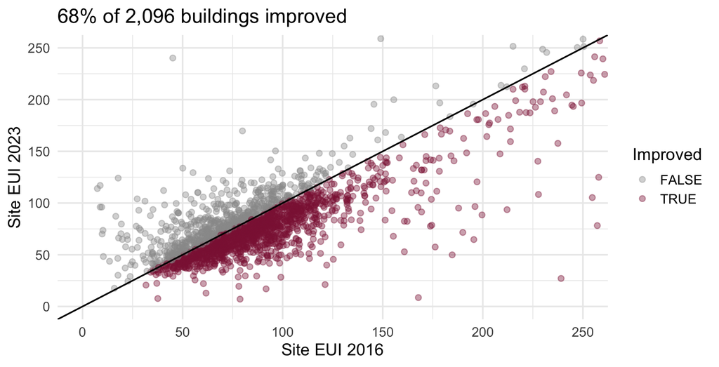

## Q1: Emissions fell even faster than energy use

- Median energy intensity, 2019 to 2023: **-14.9%**
- Median GHG intensity, 2019 to 2023: **-22.5%**
- Likely reason: a **cleaner electricity grid** (a hypothesis, not tested in this dataset)
- Takeaway: some emissions progress is not something building owners did

## Q2: Age is not a simple story

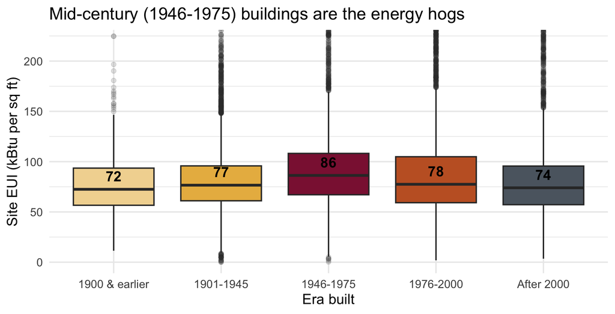

## Q3: COVID hit property types very differently

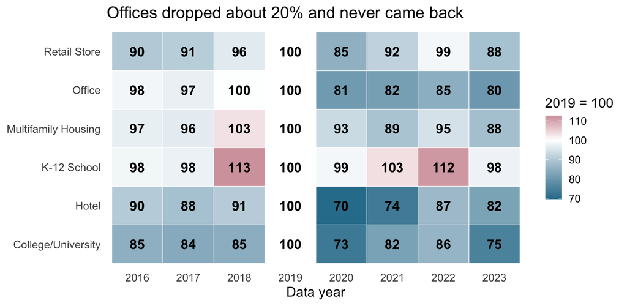

## Q4: A few property types punch above their weight

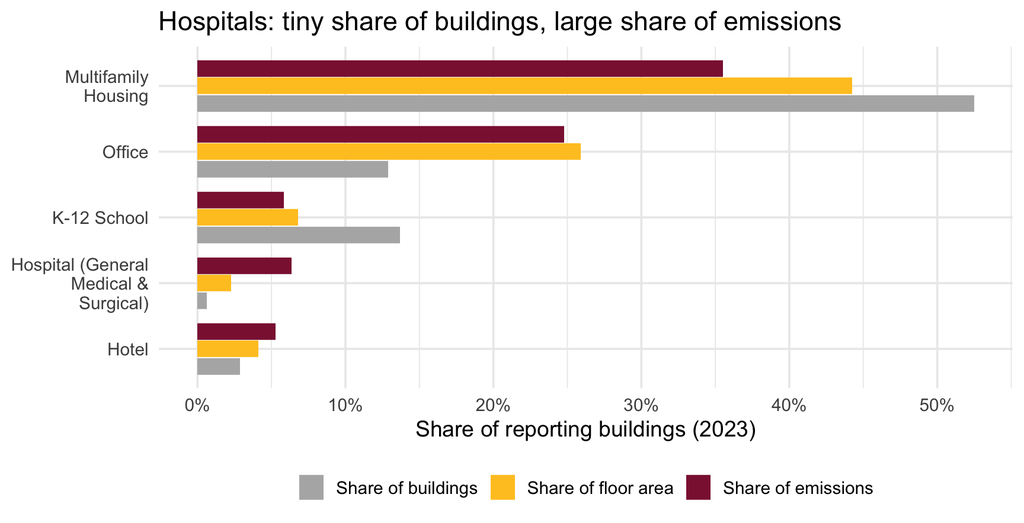

## Interactive map

[interactive chart not shown]

## Thank you! Questions?

*If you ever find yourself in a half-empty Loop office building in January, remember: it is still heated, and it still shows up in the data.*